# nNIL introgression qtl tests

Jim Holland

2024-11-21

```r
knitr::opts_chunk$set(echo = TRUE)
library(data.table)
library(tidyverse)
```

# Get data, filter, and merge BLUEs and introgression calls

Get nNIL BLUEs

```r
blues = read.csv("C:/Users/jholland/Box/nNIL genotype data Jim and Tao/GWAS/nNIL_BLUEs.csv")
```

Get introgression summaries per line so we can identify lines with uncertain origin that should be dropped

```r
line_summaries = read.csv("C:/Users/jholland/Box/nNIL genotype data Jim and Tao/nNIL_data_supplement/File_S21.filtered_nNIL_donor_match_summary.csv")

good.lines = line_summaries |>
  filter(all.intros.match.ped) |>
  pull(Line)
```

Keep only nNIL BLUEs if they are in the line_summaries data frame AND if their ped.donor matches best.match donor. This is the set of lines in good.lines object

```r
blues_filtered = blues |>
  filter(Geno %in% good.lines)
```

Get introgression calls

```r
intros = fread("C:/Users/jholland/Box/nNIL genotype data Jim and Tao/nNIL_data_supplement/File_S16.nNIL_gbs_HMM_introgressionCalls_full_set.csv")
setDF(intros) #convert from data.table to regular data.frame
colnames(intros)[1] = "Geno"
intros_filt = intros |>
  filter(Geno %in% blues_filtered$Geno)
```

Find columns of markers not identical to adjacent marker, discard redundant markers.  
First column is Geno label, 2nd column is first marker, which we always keep.  
Starting at 3rd column of data frame, check if column is NOT identical to preceding column.  
Keep columns that are NOT identical to preceding column.  
any(intros[,x] - intros[,(x-1)]) returns T if any elements are not zero.

```r
keepers = unlist(lapply((3:(ncol(intros_filt))), function(x) any(intros_filt[,x] - intros_filt[,(x-1)])))
intros_pruned = intros_filt[,c(T, T, keepers)] #keep first two columns always, Geno column and first marker column, then any non-reduntant columns in keepers
```

Drop any marker columns with no introgressions

```r
markers.no.intro = colnames(intros_pruned[-c(1)])[apply(intros_pruned[,-c(1)], 2, function(x) sum(x, na.rm = T) == 0)]
markers.no.intro
```

```
## [1] "S2_215959972"
```

```r
intros_pruned = intros_pruned[,!colnames(intros_pruned) %in% markers.no.intro]
```

Merge filtered BLUEs with pruned markers

```r
blues_intros = merge(blues_filtered, intros_pruned, by = "Geno")
```

Get list of marker names

```r
markers = colnames(blues_intros)[-c(1:19)]
```

# xTreme QTL test

Make a function to get contingency table for one trail and one marker.  
If homoz intros enriched in the tail, then run fisher test.  
Construct a data frame with p.value and counts of nNILs in or not in tail and introgression dose at a marker.

```r
tail.introgression.test = function(df, tail, marker){
  #df is the data frame with both phenotypes/tail.occurence and markers for each nNIL
  #tail is the string name of the column to test, eg 'GLS.sig.greater.B73'
  #maker is the string name of the marker column, eg 'S1_53013'
  tab = table(df[,tail], df[,marker], useNA = 'no')

  #check if 1 and 2 scores occur in data set at this marker
  hay1 = "1" %in% dimnames(tab)[[2]]
  hay2 = "2" %in% dimnames(tab)[[2]]
  #test if homozygous introgressions significantly over-represented in tail
  if (hay2) {
    #check if homoz. introgressions over-represented:
    enriched = tab["TRUE", "2"]/tab["FALSE", "2"] > tab["TRUE", "0"]/tab["FALSE", "0"]
    fisher.p = fisher.test(tab)$p.value
    #assemble a data frame with marker name, fisher.p, and the counts of introgression dosage-tail T/F
    if (hay1){ret.df = data.frame(marker = marker, tail = tail, enriched = enriched, fisher.p = fisher.p, F0 = tab["FALSE", "0"], F1 = tab["FALSE", "1"], F2 = tab["FALSE", "2"], T0 = tab["TRUE", "0"], T1 = tab["TRUE", "1"], T2 = tab["TRUE", "2"])} else {ret.df = data.frame(marker = marker, tail = tail, enriched = enriched, fisher.p = fisher.p, F0 = tab["FALSE", "0"], F1 = 0, F2 = tab["FALSE", "2"], T0 = tab["TRUE", "0"], T1 = 0, T2 = tab["TRUE", "2"])}
      return(ret.df)
    }
  return(data.frame(marker = marker, tail = tail, fisher.p = NA, F0 = NA, F1 = NA, F2 = NA, T0 = NA, T1 = NA, T2 = NA)) #return mostly empty data frame if previous checks not true
}
```

Run the tests for each tail and marker.  
Do NOT include DTA.sig.less.B73 because only 3 genotypes lines in that tail.  
Other tails have > 20 individuals at least.

```r
tail.intro.tests = list()
for (t in c("GLS.sig.less.B73", "GLS.sig.greater.B73", "NLB.sig.less.B73", "NLB.sig.greater.B73", "SLB.sig.less.B73", "SLB.sig.greater.B73", "DTA.sig.greater.B73", "EHT.sig.less.B73", "EHT.sig.greater.B73", "PHT.sig.less.B73", "PHT.sig.greater.B73")){
  for (m in colnames(blues_intros)[-c(1:19)]){
    tail.intro.tests[[paste0(t, "_", m)]] = tail.introgression.test(blues_intros, t, m)
  }
}
```

Combine results into a single df

```r
results.df = do.call(bind_rows, tail.intro.tests) |>
  mutate(log10p = -log10(fisher.p))
```

Summarize results for each tail

```r
results.df |> group_by(tail) |>
  summarize(prop.markers.sign.enriched = sum(enriched & fisher.p < 0.05)/(ncol(intros_pruned)-1))
```

```
## # A tibble: 11 × 2
##    tail                prop.markers.sign.enriched
##    <chr>                                    <dbl>
##  1 DTA.sig.greater.B73                     0.0527
##  2 EHT.sig.greater.B73                     0.0970
##  3 EHT.sig.less.B73                        0.0616
##  4 GLS.sig.greater.B73                     0.0346
##  5 GLS.sig.less.B73                        0.0616
##  6 NLB.sig.greater.B73                     0.100
##  7 NLB.sig.less.B73                        0.141
##  8 PHT.sig.greater.B73                     0.120
##  9 PHT.sig.less.B73                        0.0754
## 10 SLB.sig.greater.B73                     0.0169
## 11 SLB.sig.less.B73                        0.123
```

Check DTA.sig.greater.B73 do they match with NAM results?

```r
results.df |> filter(tail == "DTA.sig.greater.B73" & fisher.p < 0.05)
```

```
##           marker                tail enriched     fisher.p  F0 F1 F2 T0 T1 T2
## 1    S1_12336312 DTA.sig.greater.B73     TRUE 0.0227218279 502  0 16 32  1  2
## 2    S1_12540271 DTA.sig.greater.B73     TRUE 0.0203995229 503  0 15 32  1  2
## 3    S1_12711102 DTA.sig.greater.B73     TRUE 0.0227218279 502  0 16 32  1  2
## 4    S1_13005706 DTA.sig.greater.B73     TRUE 0.0456689401 505  0 13 33  1  1
## 5    S1_16415904 DTA.sig.greater.B73     TRUE 0.0319738920 506  1 11 32  1  2
## 6   S1_301052323 DTA.sig.greater.B73     TRUE 0.0456689401 505  0 13 33  1  1
## 7     S3_2758749 DTA.sig.greater.B73     TRUE 0.0428934643 508  0 10 32  0  3
## 8   S3_196703258 DTA.sig.greater.B73     TRUE 0.0121053224 509  0  9 32  1  2
## 9   S3_204489732 DTA.sig.greater.B73     TRUE 0.0344748964 509  0  9 32  0  3
## 10  S3_205743132 DTA.sig.greater.B73     TRUE 0.0428934643 508  0 10 32  0  3
## 11  S3_207944030 DTA.sig.greater.B73     TRUE 0.0428934643 508  0 10 32  0  3
## 12  S3_207990046 DTA.sig.greater.B73     TRUE 0.0344748964 509  0  9 32  0  3
## 13  S3_208294463 DTA.sig.greater.B73     TRUE 0.0270183717 510  0  8 32  0  3
## 14  S3_208298931 DTA.sig.greater.B73     TRUE 0.0205347840 511  0  7 32  0  3
```

[output cut: 263 more lines]

Q-Q plot for all tests by tail

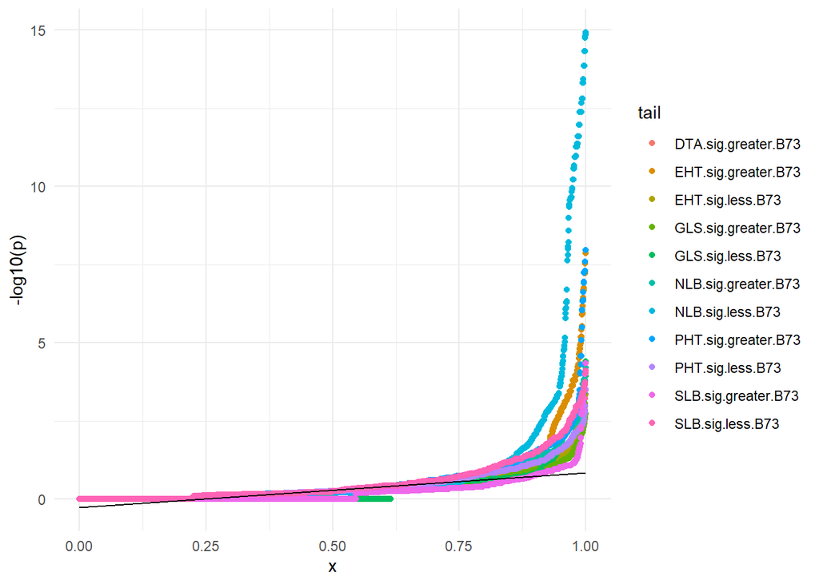

```r
ggplot(results.df, aes(sample = log10p)) + geom_qq(aes(colour = tail), distribution = stats::qunif) +
  stat_qq_line(distribution = stats::qunif, colour = "black") +
  ylab("-log10(p)")+
  theme_minimal()
```

To determine appropriate p-value threshold for multiple test correction, we use the formula of Galwey (2009) based on the eigenvalues of the marker correlation matrix.  
The squared sum of sq root eigenvalues divided by the sum of eigenvalues.

```r
corr.intros = cor(intros_pruned[-c(1)])
corr.eig = eigen(corr.intros)
summary(corr.eig$values)
```

```
##    Min. 1st Qu.  Median    Mean 3rd Qu.    Max.
##    0.00    0.00    0.00    1.00    0.00   90.22
```

Most of the eigenvalues are zero. These can be ignored for the calculation

```r
eig.values.pos = corr.eig$values[corr.eig$values > 0]
nm = ((sum(sqrt(eig.values.pos)))^2)/sum(eig.values.pos)
bonf = 0.05/nm #bonferroni critical p-value for experiment-wide alpha 0.05 correcting for effective number of tests
```

Filter the returned test values to keep only marker-tail combinations significant at bonferroni threshold

```r
sign.results.df = results.df |>
  filter(enriched & fisher.p < bonf)

sign.results.df |> group_by(tail) |>
  summarize(prop.markers.sign.enriched = n()/(ncol(intros_pruned)-1))
```

```
## # A tibble: 7 × 2
##   tail                prop.markers.sign.enriched
##   <chr>                                    <dbl>
## 1 EHT.sig.greater.B73                    0.0254
## 2 GLS.sig.less.B73                       0.00231
## 3 NLB.sig.greater.B73                    0.00462
## 4 NLB.sig.less.B73                       0.0504
## 5 PHT.sig.greater.B73                    0.0115
## 6 SLB.sig.greater.B73                    0.00231
## 7 SLB.sig.less.B73                       0.00115
```

Write out the table of markers enriched in different tails, significant according to the Bonferroni corrected p-value

```r
write.csv(sign.results.df, file = "C:/Users/jholland/Box/nNIL genotype data Jim and Tao/GWAS/Markers_sig_enriched_in_tails.csv", row.names = F, quote = F)
```

Write out the pruned introgression and trait data frame

```r
write.csv(blues_intros, file = "C:/Users/jholland/Box/nNIL genotype data Jim and Tao/nNIL_data_supplement/File_S23.nNIL_BLUEs_pruned_introgression_markers.csv", row.names = F, quote = F)
```

# QTL test for common allele effect among donors

Make a function to fit QTL tests. Model 1 fits common effect for all donor alleles at each introgression

```r
QTL_test_common_effect = function(df, trait, marker){
  y = df[[trait]]
  x = as.factor(df[[marker]])
  mod = lm(y ~ x)
  mod.sum = summary(mod)$coefficients
  mod.sum = as.data.frame(mod.sum[-c(1),c("Estimate", "Pr(>|t|)"), drop = F])
  colnames(mod.sum)[2] = "p.value"
  mod.sum[["Marker"]] = marker
  mod.sum[["Intro_Dosage"]] = row.names(mod.sum)
  mod.sum[["Trait"]] = trait
  return(mod.sum)
}
```

Run the tests

```r
results.common.effect.list = list()
for (t in c("GLS", "NLB", "SLB")){
  for (m in markers){
    results.common.effect.list[[paste0(t, "_", m)]] = QTL_test_common_effect(blues_intros, t, m)
  }
}
```

Combine results

```r
qtl.results.common.effect.df = do.call(bind_rows, results.common.effect.list)
```

Check p-value distribution

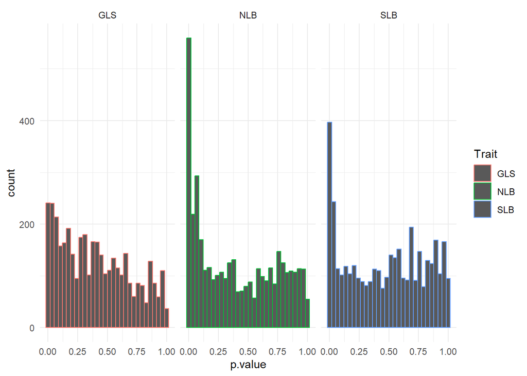

```r
ggplot(qtl.results.common.effect.df, aes(x = p.value)) + geom_histogram(aes(colour = Trait)) +
  facet_wrap(facets = vars(Trait)) +
  theme_minimal()
```

Count significant tests, using Bonferroni-corrected p-value computed above

```r
qtl.results.common.effect.df |> group_by(Trait) |>
  summarise(N.sign = sum(p.value < bonf))
```

```
## # A tibble: 3 × 2
##   Trait N.sign
##   <chr>  <int>
## 1 GLS       35
## 2 NLB      221
## 3 SLB       70
```

Plot QTL results from model with common donor effects

```r
qtl.common.effect.results.sign.df = qtl.results.common.effect.df |> filter(p.value < bonf) |>
  separate(Marker, into = c("chr", "pos"), sep = "_", remove = F) |>
  mutate(chr = as.numeric(sub("S", "", chr)),
         pos = as.numeric(pos),
         Mbp = pos/1000000,
         log10p = -log10(p.value))
```

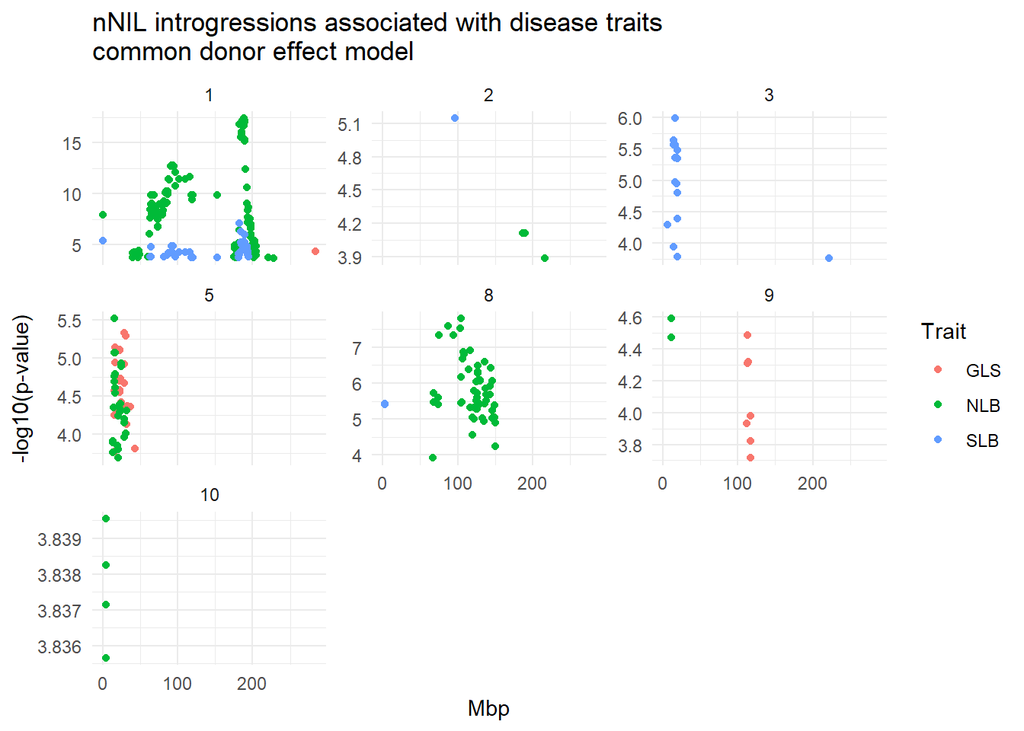

```r
qtl.common.effect.hits.plot = ggplot(qtl.common.effect.results.sign.df, aes(x = Mbp, y = log10p)) +
  geom_point(aes(colour = Trait)) +
  facet_wrap(facets = vars(chr), scales = "free_y") +
  ylab("-log10(p-value)") +
  ggtitle("nNIL introgressions associated with disease traits\ncommon donor effect model") +
  theme_minimal()
qtl.common.effect.hits.plot
```

Write out results of common QTL effect tests

```r
write.csv(qtl.common.effect.results.sign.df , file = "C:/Users/jholland/Box/nNIL genotype data Jim and Tao/GWAS/nNIL_common_introgression_effect_significant_results.csv", row.names = F, quote = F)
```

# Model selection: QTL test for common donor allele effects

Function for forward regression common effect qtl tests

```r
forwardQTL = function(df, trait, marker.df, p.thresh = 0.01){
  #df is data frame of trait data and marker scores
  #trait is character string of trait name
  #marker.df is a data.frame with two columns: Marker with character marker names and p.value which are p.values from initial QTL screen
  minp.marker = marker.df |> filter(p.value < p.thresh)
  if (nrow(minp.marker) == 0) {return(NULL)}
  minp.marker = minp.marker |> slice_min(order_by = p.value, n = 1, with_ties = F) |> pull(Marker)
  marker.df = marker.df |> filter(Marker != minp.marker)

  mod = lm(as.formula(paste(trait, " ~ 1 + ", minp.marker)), data = df) #base model
  best.mod = mod
  while (min(marker.df$p.value < 0.01)){
    results.list = list()
    for (m in marker.df$Marker){
      new.mod = update(best.mod, as.formula(paste("~ . +", m)))
      if (m %in% row.names(summary(new.mod)$coefficients)){ #if new marker causes singularity it will not be in rownames of summary, so have to check for that
      results.list[[m]] = data.frame(Marker = m, p.value = summary(new.mod)$coefficients[m,4])}
    }
    marker.df = do.call(rbind, results.list) |> filter(p.value < p.thresh)
    minp.marker = slice_min(marker.df, order_by = p.value, n = 1, with_ties = F)
    if (nrow(minp.marker) == 0) {return(best.mod)}
    minp.marker = minp.marker |> pull(Marker)
    best.mod = update(best.mod, as.formula(paste("~ . +", minp.marker)))
    marker.df = marker.df |> filter(Marker != minp.marker)
    #if no more markers to test, return best.mod
    if (nrow(marker.df) == 0) {return(best.mod)}
    }
return(best.mod)
}
```

Forward regression to select subset of markers associated with each trait.  
Filter markers to include only those with p < 0.01 as potential markers to include in model

```r
gls.multimod = forwardQTL(blues_intros, "GLS", qtl.common.effect.results.sign.df[qtl.common.effect.results.sign.df$Trait == "GLS",c("Marker", "p.value")])
nlb.multimod = forwardQTL(blues_intros, "NLB", qtl.common.effect.results.sign.df[qtl.common.effect.results.sign.df$Trait == "NLB",c("Marker", "p.value")])
slb.multimod = forwardQTL(blues_intros, "SLB", qtl.common.effect.results.sign.df[qtl.common.effect.results.sign.df$Trait == "SLB",c("Marker", "p.value")])
```

Summarize final multiple QTL model fits

```r
summary(gls.multimod)
```

```
##
## Call:
## lm(formula = GLS ~ S5_28505067 + S9_113101198, data = df)
##
## Residuals:
##      Min       1Q   Median       3Q      Max
## -0.65849 -0.16223 -0.02077  0.14686  1.34540
##
## Coefficients:
##              Estimate Std. Error t value Pr(>|t|)
## (Intercept)   3.92746    0.01164 337.546  < 2e-16 ***
## S5_28505067   0.16810    0.03549   4.737 2.76e-06 ***
## S9_113101198 -0.15309    0.03549  -4.314 1.90e-05 ***
## ---
## Signif. codes:  0 '***' 0.001 '**' 0.01 '*' 0.05 '.' 0.1 ' ' 1
##
## Residual standard error: 0.2663 on 552 degrees of freedom
## Multiple R-squared:  0.07112,    Adjusted R-squared:  0.06775
## F-statistic: 21.13 on 2 and 552 DF,  p-value: 1.437e-09
```

```r
summary(nlb.multimod)
```

```
##
## Call:
## lm(formula = NLB ~ S1_188722693 + S8_104012310 + S5_15732819 +
##     S9_11173210 + S2_215966371 + S1_42432123, data = df)
##
## Residuals:
##    Min     1Q Median     3Q    Max
## -6.083 -1.476 -0.126  1.202  8.389
##
## Coefficients:
##              Estimate Std. Error t value Pr(>|t|)
## (Intercept)  18.29595    0.09909 184.648  < 2e-16 ***
## S1_188722693 -2.45746    0.25702  -9.561  < 2e-16 ***
## S8_104012310 -1.54952    0.23908  -6.481 2.03e-10 ***
## S5_15732819   0.91798    0.24251   3.785 0.000170 ***
## S9_11173210   1.21094    0.30411   3.982 7.76e-05 ***
## S2_215966371  2.83636    0.77169   3.676 0.000261 ***
## S1_42432123  -0.78764    0.28568  -2.757 0.006026 **
## ---
## Signif. codes:  0 '***' 0.001 '**' 0.01 '*' 0.05 '.' 0.1 ' ' 1
##
## Residual standard error: 2.155 on 548 degrees of freedom
## Multiple R-squared:  0.2784, Adjusted R-squared:  0.2705
## F-statistic: 35.24 on 6 and 548 DF,  p-value: < 2.2e-16
```

```r
summary(slb.multimod)
```

```
##
## Call:
## lm(formula = SLB ~ S1_182481096 + S3_16527020 + S3_221805991 +
##     S8_2456601 + S3_6131520, data = df)
##
## Residuals:
##     Min      1Q  Median      3Q     Max
## -1.9121 -0.2405  0.0129  0.2513  2.0313
##
## Coefficients:
##              Estimate Std. Error t value Pr(>|t|)
## (Intercept)   4.46897    0.01809 247.063  < 2e-16 ***
## S1_182481096 -0.27087    0.04962  -5.459 7.27e-08 ***
## S3_16527020  -0.23571    0.06919  -3.407 0.000705 ***
## S3_221805991  0.23708    0.06455   3.673 0.000263 ***
## S8_2456601   -0.15587    0.05256  -2.966 0.003149 **
## S3_6131520   -0.18773    0.06993  -2.685 0.007479 **
## ---
## Signif. codes:  0 '***' 0.001 '**' 0.01 '*' 0.05 '.' 0.1 ' ' 1
##
## Residual standard error: 0.4042 on 549 degrees of freedom
## Multiple R-squared:  0.1356, Adjusted R-squared:  0.1277
## F-statistic: 17.22 on 5 and 549 DF,  p-value: 7.58e-16
```

# QTL for variable donor allele effects

Here we model heterogeneous allele effects for each introgression depending on the donor. To do this we need to join the BLUEs with donor information. We will use the donor matched by sequence to the introgression, and we have already dropped lines where the best.matches based on sequence is not equal to the pedigree donor.  
Get the information on donors for each line.

```r
blues_intros2 = merge(line_summaries[,c("Line", "best.matches")], blues_intros, by.x = "Line", by.y = "Geno") |>
  select(-matches("sig")) |>
  rename(donor = best.matches)
```

Make a 2nd function to test introgression*donor interactions. Now we have to treat introgression dosage as a numeric value (regressor) with common intercept at 0.  
Otherwise, if marker value is a factor, this model will fit a separate level for the non-introgressed lines for each donor, which is not what we want.  
Once we have a list of markers-traits of interest, we can get their effect estimates later.

```r
Intro_Donor_test = function(df, trait, marker){
  y = df[[trait]]
  a = as.numeric(df[[marker]])
  d = 1 - abs(a - 1)# d is 1 for het and 0 for others
  donor = as.factor(df[['donor']])
  mod = aov(y ~ a:donor + d:donor)
  mod.df = summary(mod)[[1]]
  mod.a = mod.df[grepl("^a:donor|donor:a$", trimws(row.names(mod.df))),]

  #check if any d effects in model result
  if (any(grepl("^d:donor|donor:d$", trimws(row.names(mod.df))))){
  mod.d = mod.df[grepl("^d:donor|donor:d$", trimws(row.names(mod.df))),]
  DF_dom = mod.d[1,"Df"]
  pval.dom = mod.d[1,"Pr(>F)"]} else {
    #handle case when no dominance effects in results
    DF_dom = 0
    pval.dom = NA}

  coefs = mod$coefficients
  results.df = cbind(data.frame('Marker' = marker, 'Trait' = trait, 'DF_add' = mod.a[1,"Df"], 'DF_dom' = DF_dom, pval.add = mod.a[1,"Pr(>F)"], pval.dom = pval.dom), t(coefs))
  return(results.df)
}
```

Run it

```r
donor.intro.results.list = list()
for (t in c("GLS", "NLB", "SLB")){
  for (m in markers){
    donor.intro.results.list [[paste0(t, "_", m)]] = Intro_Donor_test(blues_intros2, t, m)
  }
}
```

```r
qtl.donor.intro.results.df = do.call(bind_rows, donor.intro.results.list)
```

Check p-value distribution

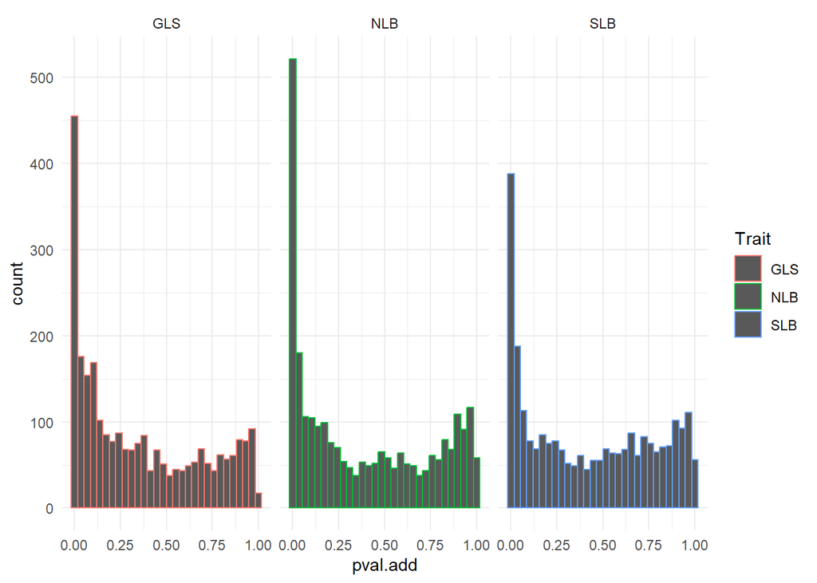

```r
ggplot(qtl.donor.intro.results.df, aes(x = pval.add)) + geom_histogram(aes(colour = Trait)) +
  facet_wrap(facets = vars(Trait)) +
  theme_minimal()
```

Display significant QTL hits across the genome

```r
qtl.donor.intro.results.sign.df = qtl.donor.intro.results.df |> filter(pval.add < bonf) |>
  separate(Marker, into = c("chr", "pos"), sep = "_", remove = F) |>
  mutate(chr = as.numeric(sub("S", "", chr)),
         pos = as.numeric(pos),
         Mbp = pos/1000000,
         log10p = -log10(pval.add))
```

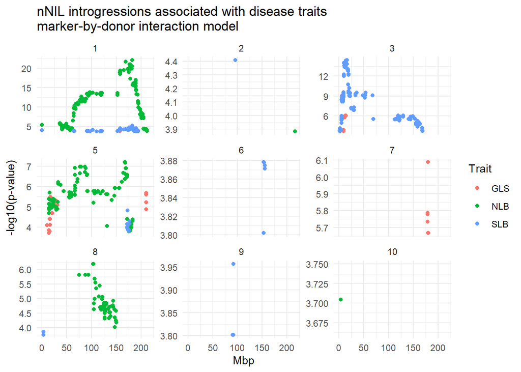

```r
qtl.donor.hits.plot = ggplot(qtl.donor.intro.results.sign.df, aes(x = Mbp, y = log10p)) +
  geom_point(aes(colour = Trait)) +
  facet_wrap(facets = vars(chr), scales = "free_y") +
  ylab("-log10(p-value)") +
  ggtitle("nNIL introgressions associated with disease traits\nmarker-by-donor interaction model") +
  theme_minimal()
qtl.donor.hits.plot
```

Write out results of donor-by-introgression QTL effect tests

```r
write.csv(qtl.donor.intro.results.sign.df , file = "C:/Users/jholland/Box/nNIL genotype data Jim and Tao/GWAS/nNIL_donor_by_introgression_interaction_significant_results.csv", row.names = F, quote = F)
```

# Model selection for QTL with variable donor effects

Function for forward regression donor*QTL interaction tests

```r
forwardQTL.donor = function(df, trait, marker.df){
  #df is data frame of trait data and marker scores
  #trait is character string of trait name
  #marker.df is a data.frame with two columns: Marker with character marker names and p.value which are p.values from initial QTL screen
  minp.marker = marker.df |> slice_min(order_by = p.value, n = 1, with_ties = F) |> pull(Marker)
  marker.df = marker.df |> filter(Marker != minp.marker)
  donor = as.factor(df[['donor']])


  mod = lm(as.formula(paste0(trait, " ~ 1 + ", minp.marker, ":donor")), data = df) #base model
  best.mod = mod
  best.aic = AIC(mod)
  keep.on = T
  while (keep.on){
    results.list = list()
    for (m in marker.df$Marker){
      new.mod = update(best.mod, as.formula(paste0("~ . +", m, ":donor")))
      results.list[[m]] = data.frame(Marker = m, aic = AIC(new.mod))}
    marker.df = do.call(rbind, results.list)
    minAIC.marker.df = slice_min(marker.df, order_by = aic, n = 1, with_ties = F)
    if (nrow(minAIC.marker.df) == 0) {return(best.mod)}
    if (minAIC.marker.df$aic >= best.aic) {return(best.mod)}
    minAIC.marker = minAIC.marker.df |> pull(Marker)
    marker.df = marker.df |> filter(Marker != minAIC.marker)
    best.mod = update(best.mod, as.formula(paste0("~ . + ", minAIC.marker, ":donor")))
    best.aic = minAIC.marker.df |> pull(aic)
    }
return(best.mod)
}
```

Forward regression to select subset of markers associated with each trait.  
Filter markers to include only those with pval.add < 0.01 as potential markers to include in model

```r
qtl.donor.intro.results.sign.gls = qtl.donor.intro.results.sign.df |>
  filter(Trait == "GLS") |>
  rename(p.value = pval.add)
gls.donor.multimod = forwardQTL.donor(blues_intros2, "GLS", qtl.donor.intro.results.sign.gls)


qtl.donor.intro.results.sign.nlb = qtl.donor.intro.results.sign.df |>
  filter(Trait == "NLB") |>
  rename(p.value = pval.add)
nlb.donor.multimod = forwardQTL.donor(blues_intros2, "NLB", qtl.donor.intro.results.sign.nlb)


qtl.donor.intro.results.sign.slb = qtl.donor.intro.results.sign.df |>
  filter(Trait == "SLB") |>
  rename(p.value = pval.add)

slb.donor.multimod = forwardQTL.donor(blues_intros2, "SLB", qtl.donor.intro.results.sign.slb )
```

Summarize final multiple QTL model fits

```r
summary(gls.donor.multimod)
```

```
##
## Call:
## lm(formula = GLS ~ S3_14337777:donor + donor:S5_16909232 + donor:S1_193840769 +
##     donor:S5_209976785 + donor:S5_22442968 + donor:S3_13020058,
##     data = df)
##
## Residuals:
##     Min      1Q  Median      3Q     Max
## -0.7061 -0.1474  0.0000  0.1319  0.9673
##
## Coefficients: (63 not defined because of singularities)
##                           Estimate Std. Error t value Pr(>|t|)
## (Intercept)               3.918944   0.011153 351.375  < 2e-16 ***
## S3_14337777:donorCML103  -0.388102   0.248159  -1.564 0.118450
## S3_14337777:donorCML228  -0.073548   0.124079  -0.593 0.553609
## S3_14337777:donorCML247   0.676956   0.124079   5.456 7.58e-08 ***
## S3_14337777:donorCML277         NA         NA      NA       NA
## S3_14337777:donorCML322   0.489630   0.124079   3.946 9.05e-05 ***
## S3_14337777:donorCML333   0.077555   0.101276   0.766 0.444163
## S3_14337777:donorCML52          NA         NA      NA       NA
## S3_14337777:donorCML69   -0.209022   0.124079  -1.685 0.092675 .
## S3_14337777:donorKi11           NA         NA      NA       NA
## S3_14337777:donorKi3     -0.057454   0.124079  -0.463 0.643530
## S3_14337777:donorM162W    0.058894   0.124079   0.475 0.635239
## S3_14337777:donorMo18W          NA         NA      NA       NA
## S3_14337777:donorNC350          NA         NA      NA       NA
## S3_14337777:donorNC358   -0.033101   0.124079  -0.267 0.789752
## S3_14337777:donorOh43           NA         NA      NA       NA
## S3_14337777:donorTx303          NA         NA      NA       NA
## S3_14337777:donorTzi8     0.005518   0.071782   0.077 0.938752
## donorCML103:S5_16909232   0.418051   0.124079   3.369 0.000810 ***
## donorCML228:S5_16909232   0.563094   0.124079   4.538 7.07e-06 ***
## donorCML247:S5_16909232         NA         NA      NA       NA
## donorCML277:S5_16909232   0.121634   0.087826   1.385 0.166671
## donorCML322:S5_16909232   0.331775   0.124079   2.674 0.007736 **
## donorCML333:S5_16909232  -0.203258   0.124079  -1.638 0.102006
## donorCML52:S5_16909232          NA         NA      NA       NA
## donorCML69:S5_16909232          NA         NA      NA       NA
## donorKi11:S5_16909232     0.036307   0.087826   0.413 0.679489
## donorKi3:S5_16909232            NA         NA      NA       NA
```

[output cut: 66 more lines]

```
## donorKi11:S3_13020058           NA         NA      NA       NA
## donorKi3:S3_13020058            NA         NA      NA       NA
## donorM162W:S3_13020058          NA         NA      NA       NA
## donorMo18W:S3_13020058          NA         NA      NA       NA
## donorNC350:S3_13020058          NA         NA      NA       NA
## donorNC358:S3_13020058          NA         NA      NA       NA
## donorOh43:S3_13020058           NA         NA      NA       NA
## donorTx303:S3_13020058   -0.180846   0.124079  -1.457 0.145588
## donorTzi8:S3_13020058           NA         NA      NA       NA
## ---
## Signif. codes:  0 '***' 0.001 '**' 0.01 '*' 0.05 '.' 0.1 ' ' 1
##
## Residual standard error: 0.2479 on 515 degrees of freedom
## Multiple R-squared:  0.2492, Adjusted R-squared:  0.1923
## F-statistic: 4.382 on 39 and 515 DF,  p-value: 2.219e-15
```

```r
summary(nlb.donor.multimod)
```

```
##
## Call:
## lm(formula = NLB ~ S1_181977859:donor + donor:S8_103049205 +
##     donor:S5_167253443 + donor:S1_168645419 + donor:S1_177789781 +
##     donor:S5_15732819 + donor:S8_107623618 + donor:S1_97108186 +
##     donor:S2_215966371 + donor:S10_4347357 + donor:S5_91461841 +
##     donor:S8_121407013 + donor:S8_124499846, data = df)
##
## Residuals:
##    Min     1Q Median     3Q    Max
## -6.054 -1.208  0.000  1.106  7.734
##
## Coefficients: (160 not defined because of singularities)
##                          Estimate Std. Error t value Pr(>|t|)
## (Intercept)              18.26701    0.09320 195.997  < 2e-16 ***
## S1_181977859:donorCML103 -3.07417    0.50048  -6.142 1.68e-09 ***
## S1_181977859:donorCML228       NA         NA      NA       NA
## S1_181977859:donorCML247       NA         NA      NA       NA
## S1_181977859:donorCML277 -2.30032    0.70625  -3.257 0.001203 **
## S1_181977859:donorCML322 -2.74264    0.99770  -2.749 0.006198 **
## S1_181977859:donorCML333 -1.34561    0.99770  -1.349 0.178048
## S1_181977859:donorCML52        NA         NA      NA       NA
## S1_181977859:donorCML69  -1.96462    0.99770  -1.969 0.049495 *
## S1_181977859:donorKi11   -6.27112    1.13547  -5.523 5.40e-08 ***
## S1_181977859:donorKi3          NA         NA      NA       NA
## S1_181977859:donorM162W  -3.27952    0.99770  -3.287 0.001084 **
## S1_181977859:donorMo18W        NA         NA      NA       NA
## S1_181977859:donorNC350        NA         NA      NA       NA
## S1_181977859:donorNC358        NA         NA      NA       NA
## S1_181977859:donorOh43    1.78886    1.40942   1.269 0.204963
## S1_181977859:donorTx303        NA         NA      NA       NA
## S1_181977859:donorTzi8   -4.33464    1.99540  -2.172 0.030307 *
## donorCML103:S8_103049205 -2.73388    2.07513  -1.317 0.188300
## donorCML228:S8_103049205 -0.16678    0.99770  -0.167 0.867308
## donorCML247:S8_103049205       NA         NA      NA       NA
## donorCML277:S8_103049205 -1.69131    0.50048  -3.379 0.000784 ***
## donorCML322:S8_103049205 -0.69473    0.99770  -0.696 0.486551
## donorCML333:S8_103049205       NA         NA      NA       NA
## donorCML52:S8_103049205  -1.09060    0.57728  -1.889 0.059449 .
## donorCML69:S8_103049205        NA         NA      NA       NA
```

[output cut: 187 more lines]

```
## donorKi11:S8_124499846         NA         NA      NA       NA
## donorKi3:S8_124499846          NA         NA      NA       NA
## donorM162W:S8_124499846        NA         NA      NA       NA
## donorMo18W:S8_124499846        NA         NA      NA       NA
## donorNC350:S8_124499846        NA         NA      NA       NA
## donorNC358:S8_124499846        NA         NA      NA       NA
## donorOh43:S8_124499846         NA         NA      NA       NA
## donorTx303:S8_124499846        NA         NA      NA       NA
## donorTzi8:S8_124499846    4.44252    1.99540   2.226 0.026440 *
## ---
## Signif. codes:  0 '***' 0.001 '**' 0.01 '*' 0.05 '.' 0.1 ' ' 1
##
## Residual standard error: 1.993 on 493 degrees of freedom
## Multiple R-squared:  0.4447, Adjusted R-squared:  0.376
## F-statistic: 6.472 on 61 and 493 DF,  p-value: < 2.2e-16
```

```r
summary(slb.donor.multimod)
```

```
##
## Call:
## lm(formula = SLB ~ S3_16527020:donor + donor:S1_181977859 + donor:S5_172788675 +
##     donor:S3_9875896 + donor:S3_30519885 + donor:S3_119352940 +
##     donor:S2_95875207 + donor:S9_92006955 + donor:S8_2930593 +
##     donor:S6_154856934 + donor:S3_9815126 + donor:S3_129683544 +
##     donor:S1_184642512 + donor:S5_172835168, data = df)
##
## Residuals:
##     Min      1Q  Median      3Q     Max
## -1.9203 -0.1838  0.0000  0.1755  1.1619
##
## Coefficients: (163 not defined because of singularities)
##                           Estimate Std. Error t value Pr(>|t|)
## (Intercept)               4.477159   0.016934 264.388  < 2e-16 ***
## S3_16527020:donorCML103  -0.287522   0.353436  -0.814 0.416332
## S3_16527020:donorCML228  -1.061499   0.249630  -4.252 2.55e-05 ***
## S3_16527020:donorCML247         NA         NA      NA       NA
## S3_16527020:donorCML277         NA         NA      NA       NA
## S3_16527020:donorCML322   0.775867   0.176718   4.390 1.39e-05 ***
## S3_16527020:donorCML333  -0.584980   0.233661  -2.504 0.012627 *
## S3_16527020:donorCML52          NA         NA      NA       NA
## S3_16527020:donorCML69   -0.895315   0.305850  -2.927 0.003582 **
## S3_16527020:donorKi11           NA         NA      NA       NA
## S3_16527020:donorKi3     -0.784933   0.176718  -4.442 1.11e-05 ***
## S3_16527020:donorM162W          NA         NA      NA       NA
## S3_16527020:donorMo18W          NA         NA      NA       NA
## S3_16527020:donorNC350          NA         NA      NA       NA
## S3_16527020:donorNC358    0.108034   0.176718   0.611 0.541269
## S3_16527020:donorOh43           NA         NA      NA       NA
## S3_16527020:donorTx303          NA         NA      NA       NA
## S3_16527020:donorTzi8    -0.695255   0.176718  -3.934 9.58e-05 ***
## donorCML103:S1_181977859 -0.452024   0.088663  -5.098 4.95e-07 ***
## donorCML228:S1_181977859        NA         NA      NA       NA
## donorCML247:S1_181977859        NA         NA      NA       NA
## donorCML277:S1_181977859 -0.095351   0.102262  -0.932 0.351588
## donorCML322:S1_181977859 -0.030588   0.176718  -0.173 0.862655
## donorCML333:S1_181977859 -0.437824   0.176718  -2.478 0.013573 *
## donorCML52:S1_181977859         NA         NA      NA       NA
## donorCML69:S1_181977859  -0.407386   0.176718  -2.305 0.021577 *
```

[output cut: 204 more lines]

```
## donorKi11:S5_172835168   -0.234481   0.161135  -1.455 0.146275
## donorKi3:S5_172835168           NA         NA      NA       NA
## donorM162W:S5_172835168         NA         NA      NA       NA
## donorMo18W:S5_172835168         NA         NA      NA       NA
## donorNC350:S5_172835168         NA         NA      NA       NA
## donorNC358:S5_172835168         NA         NA      NA       NA
## donorOh43:S5_172835168          NA         NA      NA       NA
## donorTx303:S5_172835168         NA         NA      NA       NA
## donorTzi8:S5_172835168          NA         NA      NA       NA
## ---
## Signif. codes:  0 '***' 0.001 '**' 0.01 '*' 0.05 '.' 0.1 ' ' 1
##
## Residual standard error: 0.353 on 479 degrees of freedom
## Multiple R-squared:  0.4247, Adjusted R-squared:  0.3346
## F-statistic: 4.714 on 75 and 479 DF,  p-value: < 2.2e-16
```

Combine final multi-QTL models and write to hard drive

```r
gls.common = as.data.frame(summary(gls.multimod)$coefficients)
gls.common$Marker = row.names(gls.common)
gls.common$Trait = "GLS"

nlb.common = as.data.frame(summary(nlb.multimod)$coefficients)
nlb.common$Marker = row.names(nlb.common)
nlb.common$Trait = "NLB"

slb.common = as.data.frame(summary(slb.multimod)$coefficients)
slb.common$Marker = row.names(slb.common)
slb.common$Trait = "SLB"

all.multiQTL.common = rbind(gls.common, nlb.common, slb.common)
write.csv(all.multiQTL.common, file = "C:/Users/jholland/Box/nNIL genotype data Jim and Tao/GWAS/Common_Effect_MultiQTL_Results.csv", row.names = F, quote = F)
```

```r
gls.donor = as.data.frame(summary(gls.donor.multimod)$coefficients)
gls.donor$Marker = row.names(gls.donor)
gls.donor$Trait = "GLS"

nlb.donor = as.data.frame(summary(nlb.donor.multimod)$coefficients)
nlb.donor$Marker = row.names(nlb.donor)
nlb.donor$Trait = "NLB"

slb.donor = as.data.frame(summary(slb.donor.multimod)$coefficients)
slb.donor$Marker = row.names(slb.donor)
slb.donor$Trait = "SLB"

all.multiQTL.donor = rbind(gls.donor, nlb.donor, slb.donor) |>
  filter(!is.na(Estimate))
write.csv(all.multiQTL.donor, file = "C:/Users/jholland/Box/nNIL genotype data Jim and Tao/GWAS/Donor_Effect_MultiQTL_Results.csv", row.names = F, quote = F)
```